# R Notebook

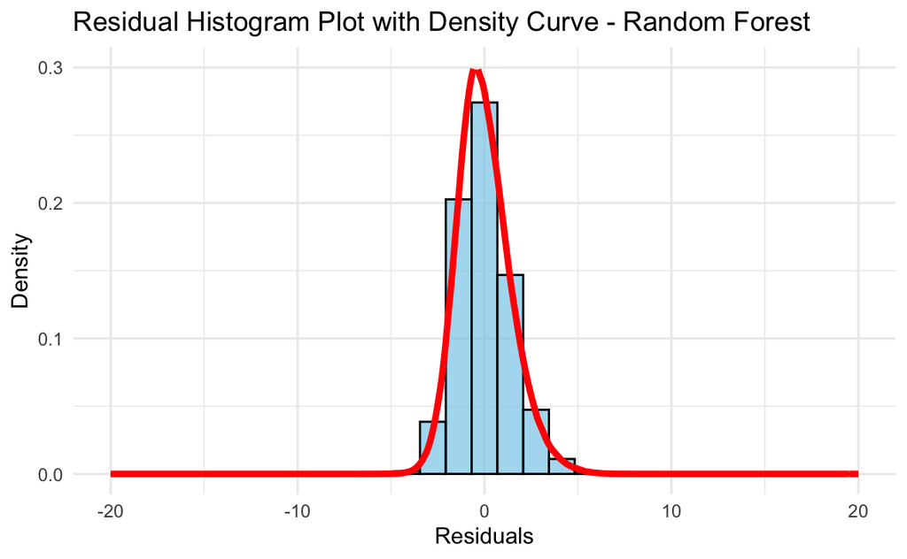

```r
print(rf_residual_histogram_plot)
```

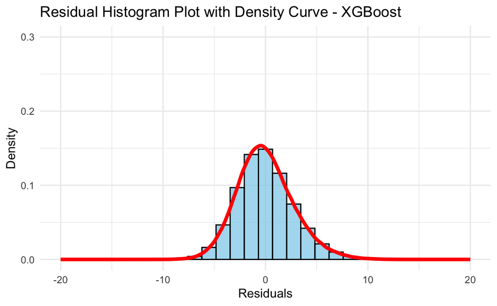

```r
print(xgb_residual_histogram_plot)
```

For each model a bar chart that displays the R-squared (coefficient of determination) values is created. R-squared measures the proportion of variance in the target variable explained by the model. Higher R-squared values indicate better model fit.

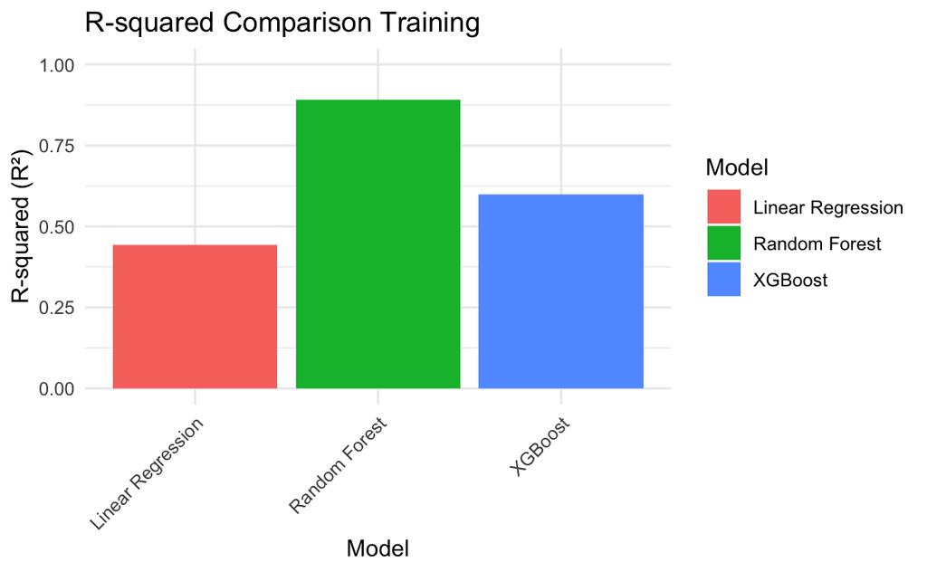

```r
# Create a data frame with R-squared values for each model
model_names <- c("Linear Regression", "Random Forest", "XGBoost")
r_squared_values_train <- c(
  lm.train_r2,
  rf.train_r2,
  xgb.train_r2
)
r_squared_values_test <- c(
  lm.test_r2,
  rf.test_r2,
  xgb.test_r2
)

r_squared_data_train <- data.frame(Model = factor(model_names),
                              R_squared = r_squared_values_train)
r_squared_data_test <- data.frame(Model = factor(model_names),
                              R_squared = r_squared_values_test)

# Create the R-squared comparison bar chart
r_squared_bar_chart_train <- ggplot(r_squared_data_train, aes(x = Model, y = R_squared, fill = Model)) +
  geom_bar(stat = "identity") +
  labs(x = "Model", y = "R-squared (R²)", title = "R-squared Comparison Training") +
  theme_minimal() +
  theme(axis.text.x = element_text(angle = 45, hjust = 1)) +
  ylim(0,1)
r_squared_bar_chart_test <- ggplot(r_squared_data_test, aes(x = Model, y = R_squared, fill = Model)) +
  geom_bar(stat = "identity") +
  labs(x = "Model", y = "R-squared (R²)", title = "R-squared Comparison Testing") +
  theme_minimal() +
  theme(axis.text.x = element_text(angle = 45, hjust = 1)) +
  ylim(0,1)

# Display the R-squared comparison bar chart
print(r_squared_bar_chart_train)
```

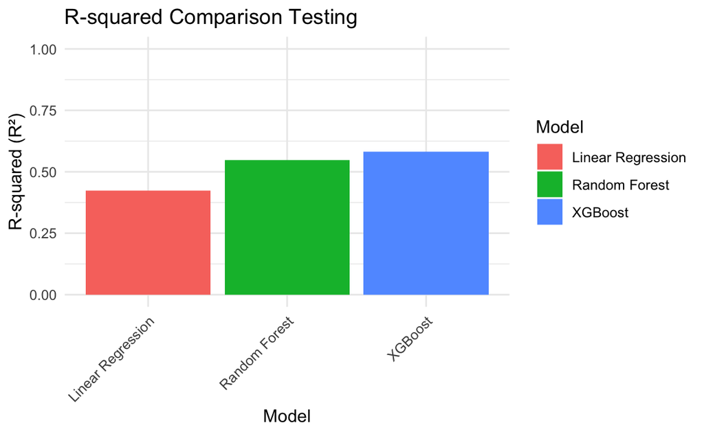

```r
print(r_squared_bar_chart_test)
```

A bar chart that compares the MAE or RMSE values, is generated for each model. These metrics quantify the average prediction errors of each model, and lower values are preferred.

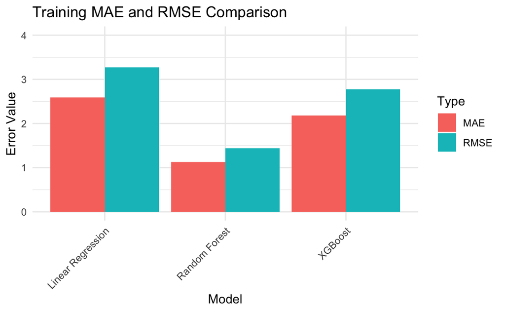

```r
# Create a data frame with MAE and RMSE values for each model
model_names <- c("Linear Regression", "Random Forest", "XGBoost","Linear Regression", "Random Forest", "XGBoost")
error_values_train <- c(
  lm.train_mae,
  rf.train_mae,
  xgb.train_mae,
  lm.train_rmse,
  rf.train_rmse,
  xgb.train_rmse
)
error_values_test <- c(
  lm.test_mae,
  rf.test_mae,
  xgb.test_mae,
  lm.test_rmse,
  rf.test_rmse,
  xgb.test_rmse
)
error_type <- c(
  "MAE", "MAE", "MAE","RMSE","RMSE","RMSE"
)
model_errors_train <- data.frame(Model = factor(model_names, levels = c("Linear Regression", "Random Forest", "XGBoost")),
                Error = error_values_train, Type = error_type)
model_errors_test <- data.frame(Model = factor(model_names, levels = c("Linear Regression", "Random Forest", "XGBoost")),
                Error = error_values_test, Type = error_type)
# Create the MAE or RMSE comparison bar chart
error_bar_chart_train <- ggplot(model_errors_train, aes(x = Model, y = Error, fill = Type)) +
  geom_bar(stat = "identity", position = "dodge") +
  labs(x = "Model", y = "Error Value", title = "Training MAE and RMSE Comparison") +
  theme_minimal() +
  theme(axis.text.x = element_text(angle = 45, hjust = 1)) +
  ylim(0, 4)

error_bar_chart_test <- ggplot(model_errors_test, aes(x = Model, y = Error, fill = Type)) +
  geom_bar(stat = "identity", position = "dodge") +
  labs(x = "Model", y = "Error Value", title = "Testing MAE and RMSE Comparison") +
  theme_minimal() +
  theme(axis.text.x = element_text(angle = 45, hjust = 1)) +
  ylim(0, 4)

# Display the MAE and RMSE comparison bar chart
print(error_bar_chart_train)
```

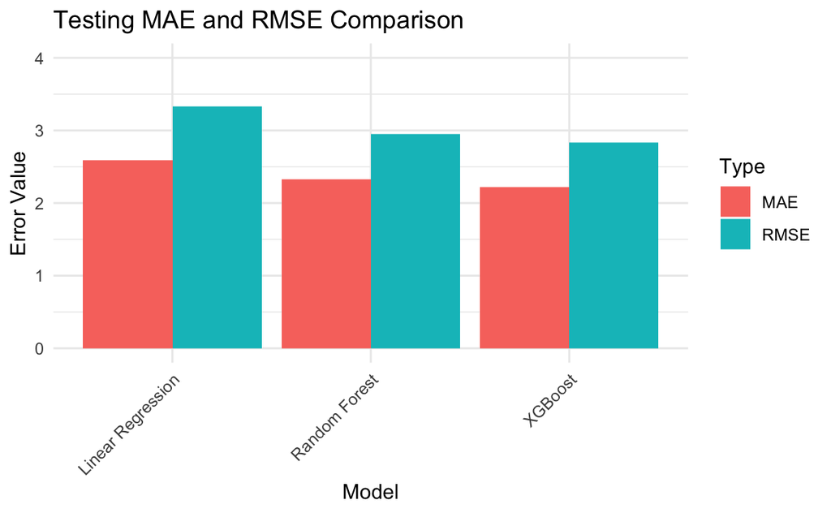

```r
print(error_bar_chart_test)
```

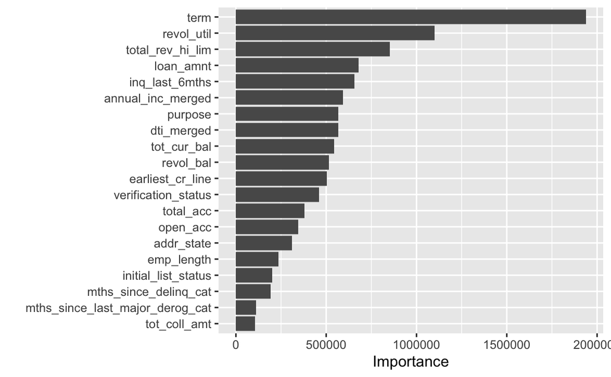

```r
#### Random Forest Feature Importance Plot ####
v1 <- vip(rf, title = "Ranger", num_features = 20)
plot(v1)
```

Learning curve using RMSE and R^2:

[figure not shown]

```r
# TODO: change the x-axes
# Create a data frame with RMSE and R-squared values for each model and sample size
model_names <- c("Linear Regression", "Random Forest", "XGBoost")
sample_sizes <- seq(10, nrow(train_data), by = 10)  # Adjust the sample sizes as needed

# Create data frames with RMSE and R-squared values for each model
rmse_data <- data.frame(
  Model = rep(model_names, each = length(sample_sizes)),
  Sample_Size = rep(sample_sizes, times = length(model_names)),
  RMSE = c(
    lm.train_rmse, rf.train_rmse, xgb.train_rmse
  )
)

r_squared_data <- data.frame(
  Model = rep(model_names, each = length(sample_sizes)),
  Sample_Size = rep(sample_sizes, times = length(model_names)),
  R_squared = c(
    lm.train_r2, rf.train_r2, xgb.train_r2
  )
)

# Create RMSE learning curve
rmse_curve <- ggplot(rmse_data, aes(x = Sample_Size, y = RMSE, color = Model)) +
  geom_line() +
  labs(x = "Sample Size", y = "RMSE", title = "RMSE Learning Curve") +
  theme_minimal()

# Create R-squared learning curve
r_squared_curve <- ggplot(r_squared_data, aes(x = Sample_Size, y = R_squared, color = Model)) +
  geom_line() +
  labs(x = "Sample Size", y = "R-squared", title = "R-squared Learning Curve") +
  theme_minimal()

# Display the RMSE and R-squared learning curves
print(rmse_curve)
```

[figure not shown]

```r
print(r_squared_curve)
```